# A review of linear models

Author

Samuele Centorrino scentorrino@proton.me

Abstract

Linear models are fundamental tools in econometrics, statistics, and data science, yet many practitioners misunderstand their underlying assumptions. This confusion often stems from conflating the estimation procedure (e.g., Ordinary Least Squares) with the statistical model itself. This note, with accompanying R code, addresses three common misconceptions about linear models: (1) error terms need not be normally distributed, (2) data need not be independent and identically distributed, and (3) error distributions may depend on regressors, allowing for heteroskedasticity, autocorrelation, and clustered dependence. I provide some simple theoretical foundations and some simulations, in which I show that one can obtain consistent and asymptotically normal estimators of the coefficients in all of these situations. Valid tests and confidence intervals can be obtained if one constructs **robust** versions of the standard errors, that account for potential heteroskedasticity and/or autocorrelation.

## The linear model

Consider the following linear model

$$Y = X\beta + \varepsilon,
\tag{1}$$

where $X$ is an observed $p$-dimensional random vector of explanatory variables, which includes a constant term, $\varepsilon$ is an unobserved random disturbance term and $Y \in \mathbb{R}$ is a continuous response variable.

The model in Equation 1 does not provide any information about the distribution of $(X,\varepsilon)$. It is a simple statistical model that postulates a linear relationship between $Y$ and $X$.

There are several separate issues about this model

1. **Identification**: does the parameter of interest can be identified from data? The answer to this question usually requires the following conditions:
1. $E(\varepsilon) = 0$
2. $Cov(X,\varepsilon) = 0$
3. $E \left[ X^\prime X \right]$ exists and is not singular
4. $E \left[ Y^2\right]$ exists

where conditions a) and b) imply that the residuals are centered, and uncorrelated with $X$; and c) and d) require the existence of the second moments of the distribution of $X$ and $Y$. In the context of time series, these assumptions are satisfies if the distribution of $(Y,X)$ is covariance stationary (otherwise those moments would not exist, see Hayashi (2000), Ch 1 for a review of the plausibility of these assumptions for time series data).[^1] Under these assumptions, we can recover the *estimand* of $\beta$ as follows (see Stock and Watson (2020), and Wooldridge (2016))

$$\begin{aligned}
X^\prime Y =& X^\prime X \beta + X^\prime \varepsilon\\
E\left[ X^\prime Y\right] =& E\left[ X^\prime X\right] \beta + \underbrace{E \left[ X^\prime \varepsilon \right]}_{= 0} \\
\beta =& \left( E\left[ X^\prime X\right] \right)^{-1} E\left[ X^\prime Y\right].
\end{aligned}$$

2. **Estimation**: how can we construct an estimator of $\beta$? Given data from the joint distribution of $(Y,X)$, $\left\lbrace (Y_i,X_i), i = 1,\dots,n \right\rbrace$, we can replace the population moments above with sample moments. Here, I use $n$ to denote the sample size, but this notation does not imply any specific assumptions on the nature of the data (i.e., it could be a time series). Let

$$\mathbf{Y}= \begin{bmatrix} Y_1 \\ \vdots \\ Y_n \end{bmatrix}, \quad \mathbf{X}= \begin{bmatrix} X_1 \\ \vdots \\ X_n \end{bmatrix},$$

we can construct the sample moments $\mathbf{X}^\prime \mathbf{Y}/n$ and $\mathbf{X}^\prime \mathbf{X}/n$, so that our estimator of $\beta$ is given by

$$\hat\beta = \left( \mathbf{X}^\prime \mathbf{X} \right)^{-1}\mathbf{X}^\prime \mathbf{Y}.
\tag{2}$$

There are a variety of theorems that allow us to prove that this estimator converges to the true value of $\beta$ as the sample size increases (this is called the law of large numbers, LLN). It suffices to say that there are versions of the LLN that apply to independent, identically distributed data (IID realizations from the distribution of $(Y,X)$); independent and non-identically distributed data (INID); and also to dependent data (for instance, to time-series, thanks to the ergodic theorem; see Hayashi (2000), Ch. 1 and 9). Most of these theorems do not require further conditions than those outlined above (existence of certain moments of the distribution of $(Y,X)$).[^2]

3. **Inference**: how do we assess the variability of our estimator, test specific hypotheses and/or construct prediction intervals? We usually need to have a way to show that the distribution of the estimator around the true value of $\beta$ (which exists under the conditions in 1), is well behaved (i.e., targets the correct population parameter and has finite variance). There are two types of results that one can be interested in
   1. **Finite sample properties**: when $n$ is relatively small, we could be interested in assumptions that would allow us to derive the distribution of the estimator. Such assumptions usually restrict the distribution of $\varepsilon$. In particular, one can have that $\varepsilon_i \sim N(0, \sigma^2)$. This assumption implies full independence between the regressors $X$, and the error term. It also entails *homoskedasticity* of the error term (i.e., the variance is the same irrespectively of the value of $X$).
   2. **Large sample properties**: when $n$ is large, we do not require any assumptions about the distribution of $\varepsilon$. Additional requirements include that the fourth moments of the distribution of $Y$ and $X$ exist (see Stock and Watson (2020), Chapter 3). The Central Limit Theorem (CLT) allows us to prove that, with minimal assumptions on the Data Generating Process (DGP), the distribution of the OLS estimator in Equation 2 converges to a normal distribution.

The reason why finite sample results were (and still are) the initial focus of econometric textbooks, in my opinion, is mainly related to historical reasons. For instance, the textbook by Stock and Watson (2020) does not treat the finite-sample properties of the OLS estimator. To a certain extent, I agree that in the era of *big data*, results in $a$ may have limited relevance. In the next section I show numerically that the normal approximation in $b$ holds even with as few as $100$ data points, so that, in my opinion, in many practical applications (and when the model is correctly specified) we should not worry about deviations from gaussianity.

However, there are also other considerations that may be important. For instance, one may be concerned with the **efficiency** of the estimator (i.e., obtaining the estimator with the smallest possible variance). The Gauss-Markov theorem shows that the OLS estimator is the most efficient when the error term is homoskedastic (i.e. the variance of $\varepsilon$ does not depend on $X$). This is a statement about the second moment of the distribution of $\hat{\beta}$, and not about its distribution. So the Gauss-Markov theorem (which is still a very important result in statistics and very useful to understand the concept of efficiency) does not require assumptions about the distribution of $\varepsilon$ to hold. Moreover, even if the OLS may not be the most efficient when homoskedasticity is violated, it is still consistent. One just needs to be careful about the way its standard errors are being estimated. But this is very different from saying that the linear model does not work when the error term is not normal and when there is heteroskedasticity or autocorrelation in the residuals. One just needs to modify the computation of its standard error (i.e. the way we measure the uncertainty of that estimator) to take those features into account.

The misconception about the assumptions needed for consistent estimation of the parameters of a linear model has, in my opinion, two main drivers:

1. **Misunderstanding the results of the CLT.** A common myth is that if the distribution of the estimator is normal, then the underlying distribution of the data must be normal as well. This is **false**. As long as certain moments of the underlying distribution of the data exist, the estimators we use (and in particular, the OLS estimator in Equation 2) are constructed using averages. These averages are well-behaved so that, when $n$ is sufficiently large, the uncertainty can be characterized by a normal distribution. These approximation do not work only when certain moments of the distribution of the data do not exist (i.e., Cauchy).
2. **Gaussian implies linear, and linear implies Gaussian.** It is true that, if the distribution of $(Y,X)$ is jointly normal, the conditional expectation of $Y$ given $X$ is a linear function of $X$, and that $Y$ can be characterized by the sum of its conditional expectation (a liner function of $X$) plus a normal random variable which is independent of $X$ (basically a linear model). But then the latter implication is not necessarily true. We can construct a DGP in which the conditional expectation of $Y$ given $X$ is linear, even if the joint distribution is not a normal distribution (see below). Moreover, there is an important distinction between a model linear in $X$ and a model that is linear in $\beta$. We can still include nonlinearities in the latter by introducing polynomial terms or monotone transformations of $X$. So the use case of a model linear in parameter is not confined to the Gaussian world.

## Simulations

I would like to verify, using simulations, some of the claims made in the previous section. This is not an exhaustive exercise, and it is meant to give an idea about the practical implications of using robust standard errors when homoskedasticity is not satisfied. The code of these simulations is provided, so that readers should feel free to explore with different data-generating processes (DGPs).

We first load the R libraries that we require for this simple exercise.

```r
library(knitr)
library(sandwich)
```

In particular, the R library `sandwich` allows us to construct several estimators of the standard errors that are robust to heteroskedasticity and autocorrelation in the residuals (see, e.g., White (1980) and Newey and West (1987)).

Throughout this session, I vary the sample size $n= \lbrace 100,250,500,1000 \rbrace$ to assess how the properties of our estimator improve as $n$ increases. Also, our goal is to show that the distribution of the estimator in finite but large samples is approximately normal.

### Regression model with IID data when the error term is non-normally distributed.

Let us fix $n = 100$, and consider the following DGP

```r
set.seed(42)

meaneps <- 0.75*sqrt(2/pi)
vareps <- 0.25^2 +  (0.75^2)*(1 - 2/pi)

dgp_fun_1 <- function(n){

        epsilon <- 0.25*rnorm(n) + 0.75*abs(rnorm(n))

        x <- runif(n)

        y <- 1 + x + (epsilon - meaneps)

        return(data.frame(y = y, x = x, error = epsilon - mean(epsilon)))
}

data_ex_1 <- dgp_fun_1(100)

error_std <- data_ex_1$error/sd(data_ex_1$error)
```

I take $\beta_0 = \beta_1 = 1$, $X\sim Unif[0,1]$, and the error term to follow a skew-normal distribution (a linear combination between a normal random variable and a half-normal random variable, see Azzalini (2013)), which is clearly asymmetric, as shown in Figure 1. The error term in this first simple exercise is take to be fully independent of $X$. Its mean is not zero, so I centered it to satisfy the assumption that $E(\varepsilon) = 0$.[^3]

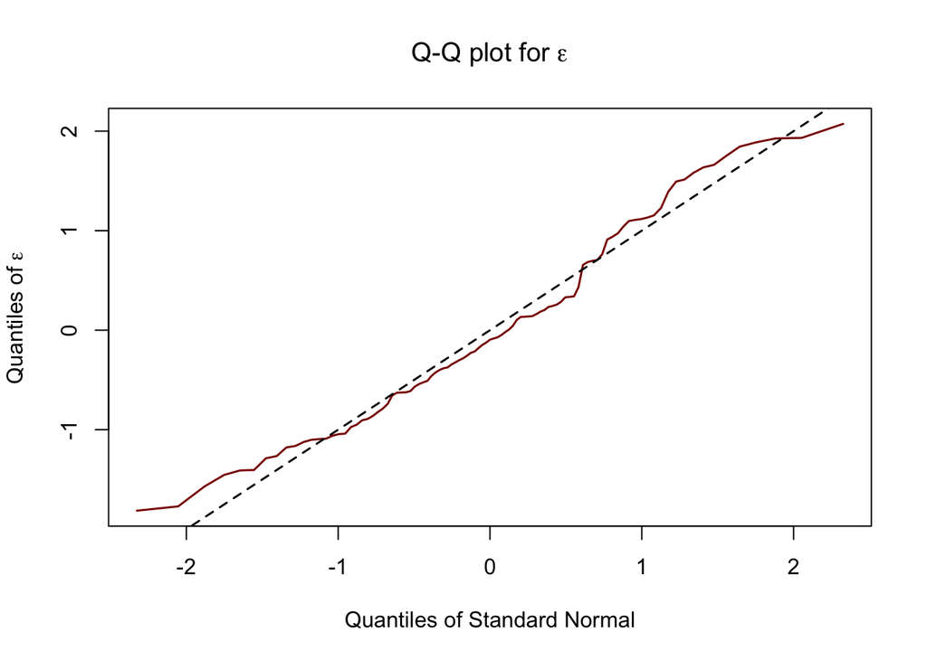

Figure 1: QQ-plot of the standardized distribution of the error term.

In Table 1, we report the results for the estimation with one random sample, where we also report the $95\%$ confidence interval.

Table 1: Results for a randomly selected sample of $n = 100$ observations.

|  | Estimate | Std. Error | CI(95%) LB | CI(95%) UB |
| --- | --- | --- | --- | --- |
| $\hat{\beta}_0$ | 0.926 | 0.084 | 0.760 | 1.093 |
| $\hat{\beta}_1$ | 1.031 | 0.154 | 0.726 | 1.337 |

The coefficients have the expected sign and magnitude, and the $95\%$ confidence intervals cover the true value of the parameter. In R, the standard errors with the default `lm` command are computed under the assumption of homoskedasticity, which we know is satisfied in this case as the error term is fully independent of $X$.

Let us now run a large scale simulation exercise with $R = 10000$ replications for increasing sample size. The goal of this exercise is to show that:

1. The coefficients converge to their true value as $n$ increases.
2. The distribution of the coefficients is approximately normal, and the approximation improves as $n$ increases, even if the distribution of the error term is not normal.

I produce the qq-plots of the distribution of $\hat{\beta} - \beta$ normalized by its standard error, which theoretically is equal to the square-root of the diagonal of this matrix

$$\sigma^2 \left[ E \begin{pmatrix} 1 & X \\ X & X^2 \end{pmatrix}\right]^{-1} = \sigma^2\left[ \begin{pmatrix} 1 & 1/2 \\ 1/2 & 1/3 \end{pmatrix}\right]^{-1} = \sigma^2 \begin{pmatrix} 4 & -6 \\ -6 & 12 \end{pmatrix},$$
where $\sigma^2 = 0.267$.

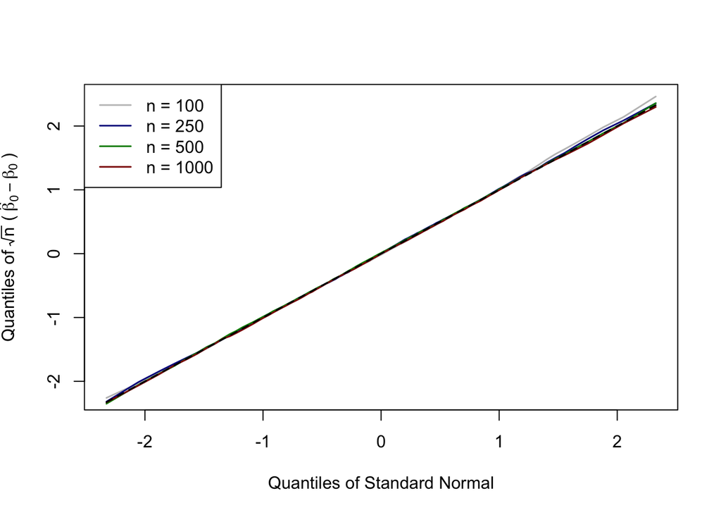

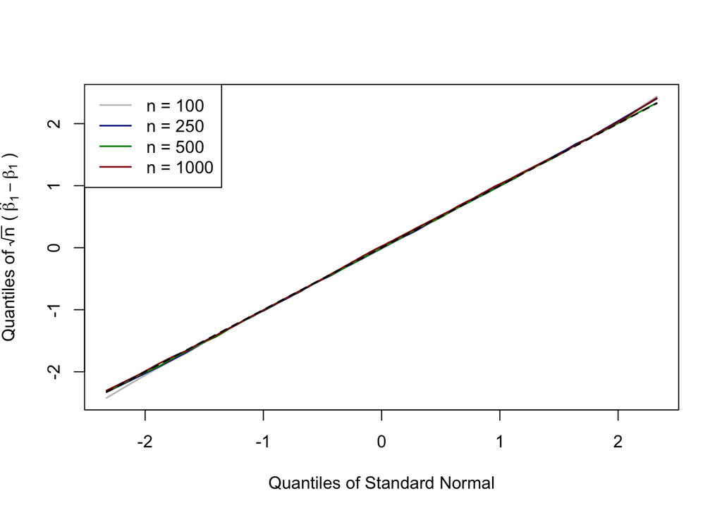

Figure 2: QQ-plot of the regression coefficients for different sample sizes.

In Figure 2 the lines are indistinguishable, showing that the normal approximation works well for sample sizes as small as $n = 100$.

**Take home message 1**: the linear model can be used even when the error is not normally distributed, as the OLS estimator preserves its good large-sample properties, and it is still the most efficient because of the Gauss-Markov theorem.

### Regression model with IID data when the error term is non-normally distributed and heteroskedastic

Let us consider the same example as before, and let us now add heteroskedasticity of the error term through a linear function, with $n = 100$.

```r
set.seed(42)

meaneps <- 0.75*sqrt(2/pi)
vareps <- 0.25^2 +  (0.75^2)*(1 - 2/pi)

dgp_fun_2 <- function(n){

        epsilon <- 0.25*rnorm(n) + 0.75*abs(rnorm(n))

        x <- runif(n)

        y <- 1 + x + sqrt(3/7)*(1 + x)*(epsilon - meaneps)

        return(data.frame(y = y, x = x, error = epsilon - mean(epsilon)))
}

data_ex_2 <- dgp_fun_2(100)
```

Table 2: Results for a randomly selected sample of $n = 100$ observations where standard errors are not corrected for heteroskedasticity.

|  | Estimate | Std. Error | CI(95%) LB | CI(95%) UB |
| --- | --- | --- | --- | --- |
| $\hat{\beta}_0$ | 0.940 | 0.084 | 0.774 | 1.106 |
| $\hat{\beta}_1$ | 1.011 | 0.154 | 0.706 | 1.316 |

The results in Table 2 seems very consistent with our results above: The estimator is still very close to the true value, which is not surprising, because heteroskedasticity does not affect our ability to estimate $\beta$, and true value of the parameter is still within the $95\%$ confidence interval. However, the standard errors are not correct in this example, because they ignore heteroskedasticity, which affects our confidence intervals, and therefore our ability to correctly assess the uncertainty of our point estimate.

With the package `sandwich` in R, we can compute standard errors that are robust to heteroskedasticity of various form

I modify the standard errors and confidence intervals in the previous tables, using now their heteroskedasticity-robust version. Results are reported in Table 3.

Table 3: Results for a randomly selected sample of $n = 100$ observations with heteroskedasticity robust standard errors.

|  | Estimate | Std. Error | CI(95%) LB | CI(95%) UB |
| --- | --- | --- | --- | --- |
| $\hat{\beta}_0$ | 0.940 | 0.069 | 0.806 | 1.075 |
| $\hat{\beta}_1$ | 1.011 | 0.167 | 0.684 | 1.338 |

Table 4: Coverage rates with different estimates for standard errors.

|  | Homoskedastic 90% | Homoskedastic 95% | Homoskedastic 99% | Heteroskedastic 90% | Heteroskedastic 95% | Heteroskedastic 99% |
| --- | --- | --- | --- | --- | --- | --- |
| \(\mathbf{\hat{\beta}_0}\) |  |  |  |  |  |  |
| n = 100 | 0.948 | 0.979 | 0.998 | 0.889 | 0.944 | 0.988 |
| n = 250 | 0.950 | 0.981 | 0.999 | 0.895 | 0.948 | 0.989 |
| n = 500 | 0.951 | 0.980 | 0.997 | 0.898 | 0.948 | 0.988 |
| n = 1000 | 0.952 | 0.980 | 0.998 | 0.900 | 0.949 | 0.989 |
| \(\mathbf{\hat{\beta}_1}\) |  |  |  |  |  |  |
| n = 100 | 0.893 | 0.942 | 0.987 | 0.888 | 0.939 | 0.984 |
| n = 250 | 0.890 | 0.943 | 0.989 | 0.892 | 0.944 | 0.987 |
| n = 500 | 0.890 | 0.944 | 0.989 | 0.894 | 0.946 | 0.989 |
| n = 1000 | 0.892 | 0.946 | 0.987 | 0.897 | 0.948 | 0.988 |

**Take home message 2**: you can still use the linear model when you have heteroskedasticity. Just make sure that you account for it when you construct your standard errors, using heteroskedasticity-robust estimate.

### Regression model with time-series data when the error term is non-normally distributed and auto-correlated

Let us consider a different data-generating process, when the error term is allowed to be autocorrelated and heteroskedastic. I don’t generate autocorrelation in the regressor, but there is going to be autocorrelation in the dependent variable, because of the autocorrelation in the error term. I define the error term as following an auto-regressive process of order $1$, where the autoregressive parameter $\rho= 0.8$. If we let $\sigma^2_\varepsilon = Var(\varepsilon)$, and

$$U_i = \rho U_{i - 1} + \varepsilon_i,$$

then $E(U) = 0$, and $Var(U) = \sigma^2_\varepsilon/(1 - \rho^2)$. Therefore, in the simulation, I multiply the error term by $(1 - \rho^2)$, so that the error to noise ratio is comparable to the previous simulation scheme, where I only introduce heteroskedasticity.

As before, let us start with a sample of modest size $n = 100$. Here, when simulating the autoregressive model, I burn the first $1000$ data points to allow the process to reach its stationary path.

```r
set.seed(42)

meaneps <- 0.75*sqrt(2/pi)
vareps <- 0.25^2 + (0.75^2)*(1 - 2/pi)

burn <- 1000
dgp_fun_3 <- function(n){

        epsilon <- 0.25*rnorm(n+burn) + 0.75*abs(rnorm(n+burn))

        u <- integer(n + burn)
        rho <- 0.8
        u[1] <- epsilon[1] - meaneps
        for(dd in 2:(n + burn)){
          u[dd] <- rho*u[dd-1] + (epsilon[dd] - meaneps)
        }
        u <- u[(burn + 1):(n+burn)]
        x <- runif(n)

        y <- 1 + x + sqrt(3/7)*(1 - rho^2)*(1 + x)*u

        return(data.frame(y = y, x = x, error = u))
}

data_ex_3 <- dgp_fun_3(100)
```

Table 5: Results for a randomly selected sample of $n = 100$ observations where standard errors are not corrected for heteroskedasticity and autocorrelation.

|  | Estimate | Std. Error | CI(95%) LB | CI(95%) UB |
| --- | --- | --- | --- | --- |
| $\hat{\beta}_0$ | 0.909 | 0.078 | 0.755 | 1.063 |
| $\hat{\beta}_1$ | 1.087 | 0.129 | 0.832 | 1.342 |

With the package `sandwich` in R, we can compute standard errors that are robust to heteroskedasticity and autocorrelation following the approach of Newey and West (1987).

We modify the standard errors and confidence intervals in the previous tables, using now their heteroskedasticity and autocorrelation-robust version. Results are reported in Table 6.

Table 6: Results for a randomly selected sample of $n = 100$ observations with heteroskedasticity and autocorrelation robust standard errors.

|  | Estimate | Std. Error | CI(95%) LB | CI(95%) UB |
| --- | --- | --- | --- | --- |
| $\hat{\beta}_0$ | 0.909 | 0.041 | 0.828 | 0.990 |
| $\hat{\beta}_1$ | 1.087 | 0.143 | 0.807 | 1.367 |

Let me repeat the same large-scale simulation as before, comparing the coverage rate in both cases.

Table 7: Coverage rates with different estimates for standard errors.

|  | Homoskedastic 90% | Homoskedastic 95% | Homoskedastic 99% | Heteroskedastic 90% | Heteroskedastic 95% | Heteroskedastic 99% |
| --- | --- | --- | --- | --- | --- | --- |
| \(\mathbf{\hat{\beta}_0}\) |  |  |  |  |  |  |
| n = 100 | 0.801 | 0.874 | 0.956 | 0.708 | 0.778 | 0.880 |
| n = 250 | 0.817 | 0.882 | 0.960 | 0.767 | 0.839 | 0.928 |
| n = 500 | 0.808 | 0.880 | 0.959 | 0.791 | 0.860 | 0.946 |
| n = 1000 | 0.807 | 0.885 | 0.959 | 0.807 | 0.880 | 0.958 |
| \(\mathbf{\hat{\beta}_1}\) |  |  |  |  |  |  |
| n = 100 | 0.847 | 0.913 | 0.976 | 0.624 | 0.710 | 0.828 |
| n = 250 | 0.846 | 0.913 | 0.974 | 0.669 | 0.755 | 0.866 |
| n = 500 | 0.857 | 0.918 | 0.977 | 0.690 | 0.774 | 0.883 |
| n = 1000 | 0.851 | 0.915 | 0.978 | 0.695 | 0.783 | 0.895 |

## How to detect deviations from homoskedasticity?

How do we know what type of robust estimate to use for the standard errors? Ideally, we could plot, explore and test our data to decide. One can use the Breusch-Pagan test for heteroskedasticity and, if you have time-series, you can run autocorrelation tests on the OLS residuals (e.g., Durbin-Watson test).

You can also use the wild bootstrap to obtain a finite-sample approximation to the asymptotic distribution of your data. This procedure is robust to heteroskedasticity (Liu (1988),Davidson and Flachaire (2008)), and modifications of it can be used for dependent data (Shao (2010)).

## References

Azzalini, Adelchi. 2013. *The Skew-Normal and Related Families*. Institute of Mathematical Statistics Monographs. Cambridge University Press.

Davidson, Russell, and Emmanuel Flachaire. 2008. “The Wild Bootstrap, Tamed at Last.” *Journal of Econometrics* 146 (1): 162–69. https://doi.org/https://doi.org/10.1016/j.jeconom.2008.08.003.

Hayashi, F. 2000. *Econometrics*. Princeton University Press.

Liu, Regina Y. 1988. “Bootstrap Procedures under some Non-I.I.D. Models.” *The Annals of Statistics* 16 (4): 1696–1708. https://doi.org/10.1214/aos/1176351062.

Newey, Whitney K., and Kenneth D. West. 1987. “A Simple, Positive Semi-Definite, Heteroskedasticity and Autocorrelation Consistent Covariance Matrix.” *Econometrica* 55 (3): 703–8.

Shao, Xiaofeng. 2010. “The Dependent Wild Bootstrap.” *Journal of the American Statistical Association* 105 (489): 218–35. https://doi.org/10.1198/jasa.2009.tm08744.

Stock, J. H., and M. W. Watson. 2020. *Introduction to Econometrics*. 4th ed. Pearson.

White, Halbert. 1980. “A Heteroskedasticity-Consistent Covariance Matrix Estimator and a Direct Test for Heteroskedasticity.” *Econometrica* 48 (4): 817–38.

Wooldridge, J. M. 2016. *Introductory Econometrics: A Modern Approach*. Cengage Learning.

## Footnotes

[^1]: Ch. 1 can also be downloaded [here](https://daniellecarusi.wordpress.com/wp-content/uploads/2009/07/s6946.pdf).
[^2]: If you are interested in the details, you can check these [lecture notes](https://cameron.econ.ucdavis.edu/e240a/asymptotic.pdf) by Colin Cameron.
[^3]: If the error term has a non-zero mean, we would not be able to identify the parameter $\beta_0$.